# 11/25 Notes

Author

Sepehr Akbari

Published

November 25, 2024

# 11/18 notes

## More parenting regrssion

```r
library(tidyverse)
library(readxl)
library(broom)

parenting <- read_excel("../Data/parenting.xlsx")
```

We view this as a random sample, imagining a much larger population of days with the same variables. We might be interested in whether there is a relationship between two quantitative variables, like `baby.sleep` and `dan.grump`. Linear regression does this, specifically testing for a linear relationship.

NULL: The average of `dan.grump` (the response variable) is not linearly related to the value of `baby.sleep` (the explanatory variable).

ALT: The average of `dan.grump` is linearly related to the value of `baby.sleep`. Specifically, the slope of the regression line is not zero.

As usual you should set hypotheses before looking at the sample data. You should also make a plot (we did this on 11/15).

```r
model <- lm(dan.grump ~ baby.sleep, data = parenting)
summary(model)
```

```
Call:
lm(formula = dan.grump ~ baby.sleep, data = parenting)

Residuals:
     Min       1Q   Median       3Q      Max
-21.4190  -5.0049  -0.0587   4.9567  23.7275

Coefficients:
            Estimate Std. Error t value Pr(>|t|)
(Intercept)  85.7817     3.3528  25.585  < 2e-16 ***
baby.sleep   -2.7421     0.4035  -6.796 8.45e-10 ***
---
Signif. codes:  0 '***' 0.001 '**' 0.01 '*' 0.05 '.' 0.1 ' ' 1

Residual standard error: 8.327 on 98 degrees of freedom
Multiple R-squared:  0.3203,    Adjusted R-squared:  0.3134
F-statistic: 46.18 on 1 and 98 DF,  p-value: 8.448e-10
```

The p-value is very small so we reject the null hypotheses. There is strong evidence that daniel’s mood is not independent from the amount of sleep her baby got.

## Using a regression line

We use the regression model to make predictions, by plugging into the equation, so the equation of the line her is:

$$dan.grump = 85.8 - 2.7 \times baby.sleep$$

Suppose the baby gets 7.92 hours of sleep. We predict Daniel’s mood to be $85.8 - 2.7 \times 7.92 = 64.4$. This is called a *fitted value*.

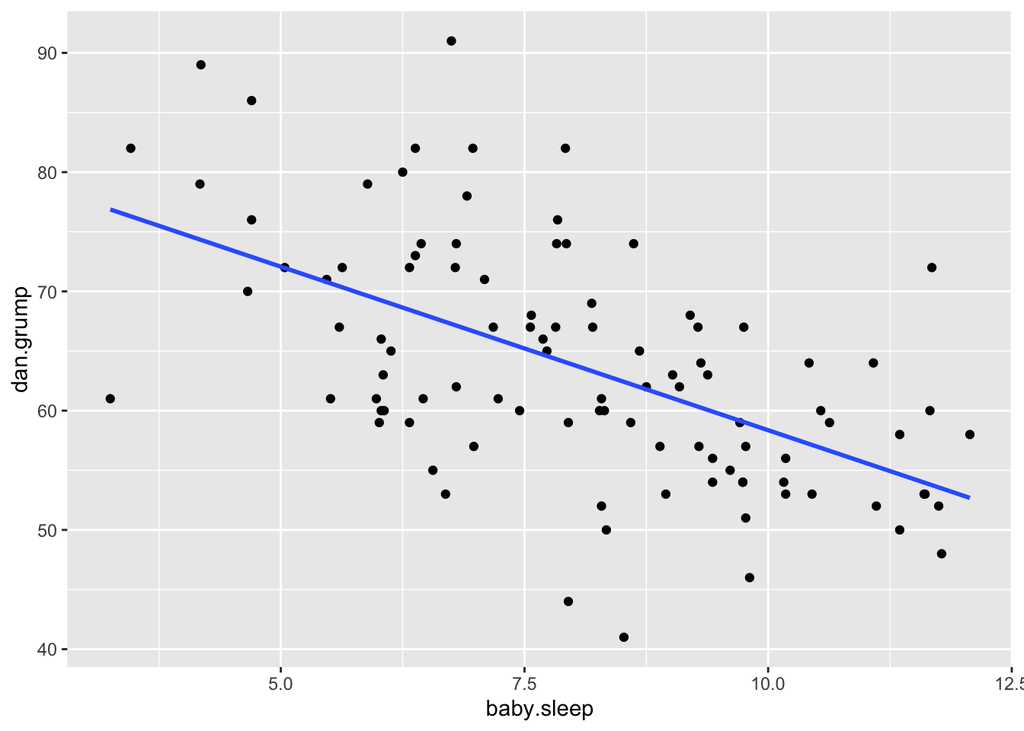

```r
ggplot(
  parenting,
  aes(x = baby.sleep,
      y = dan.grump)
) +
  geom_point() +
  geom_smooth(method = "lm",
              se = FALSE)
```

In our dataset, there is a point baby slept 7.92 hours and Daniel’s mood the next day 82. Our prediction was off. The difference is called *residual* of the observation.

*The formula is: residual = observed - fitted.*

For this observation, the residual is $82 - 64.4 = 17.6$.

The residual represents th vertical distance from the line to the point. Positive values mean the point is above the line, negative values mean the point is below the line.

## Assumptions & Diagnostics

Linear regression has 4 basic assumptions:

- The relationship between variables is linear, at least mostly.
- The observations are independent of one another. This is a study design issue and stats can’t do anything about it.
- For every x-value, the residuals are normally distributed.
- For every x-value, the variance of the residuals is the equal.

The acronym “LINE” summarizes this. All 4 of these must hold if inference is to be valid. The first two are essential, the last two are less impactful unless the sample size is small.

## Checking Assumptions (model diagnostics)

The initial scatterplot was a good first step for checking assumptions. But its not as clear as what we really want, so we check our model afterwards with a residual plot. To make one we need residuals and fitted values for all our observations. Let’s do it in two ways

First, we have R functions to extract them.

```r
fitted.values(model)
```

```
       1        2        3        4        5        6        7        8
57.86714 53.80883 64.06428 59.43013 59.04624 71.96152 57.12677 63.10454
       9       10       11       12       13       14       15       16
69.16458 66.34022 53.75399 68.97264 64.31107 70.42595 69.24685 63.32391
      17       18       19       20       21       22       23       24
68.28711 55.31698 70.67274 67.43706 59.07366 61.04797 68.12259 59.92371
      25       26       27       28       29       30       31       32
76.29404 68.45164 63.98202 64.69496 65.35307 65.05143 63.98202 53.94593
      33       34       35       36       37       38       39       40
72.89384 62.41902 72.89384 62.96744 60.06081 74.31973 69.38395 60.30760
      41       42       43       44       45       46       47       48
69.30169 56.87998 53.47978 53.97336 54.65888 70.34369 66.64185 69.24685
      49       50       51       52       53       54       55       56
73.00352 58.88171 52.68457 65.02401 54.65888 70.78242 63.04970 67.13543
      57       58       59       60       61       62       63       64
56.63319 62.22707 64.33849 66.09343 63.04970 55.39925 68.06774 76.86988
      65       66       67       68       69       70       71       72
59.07366 61.78834 53.56204 60.25276 64.58528 61.98028 58.99140 59.15592
      73       74       75       76       77       78       79       80
74.34715 57.86714 60.33502 65.95633 68.28711 60.55439 63.29649 57.92198
      81       82       83       84       85       86       87       88
61.23992 67.13543 62.91260 68.64358 67.27253 60.85602 57.20903 61.40444
      89       90       91       92       93       94       95       96
59.92371 67.16285 66.83380 69.19200 68.45164 62.14481 64.28365 69.63074
      97       98       99      100
58.99140 66.66927 67.79353 64.03686
```

```r
residuals(model)
```

```
           1            2            3            4            5            6
 -1.86713601   6.19117012  17.93572084  -4.43013229   7.95376153   0.03847648
           7            8            9           10           11           12
 -4.12676935  -3.10454460  -9.16458281   4.65977889  18.24601210  -3.97263590
          13           14           15           16           17           18
  9.68893196  -3.42594823  -3.24684577   5.67608750   4.71288879  -3.31698418
          19           20           21           22           23           24
 -9.67273712 -14.43706060  -5.07365945   1.95202946   5.87741471  -3.92371006
          25           26           27           28           29           30
  5.70596047   3.54836286  -4.98201619   1.30503813  -5.35306556   1.94856530
          31           32           33           34           35           36
-19.98201619  -0.94593481   3.10616291 -21.41901991  13.10616291  -2.96743966
          37           38           39           40           41           42
  2.93918500  14.68027156  -8.38395071  -3.30760389 -10.30168775   3.12001954
          43           44           45           46           47           48
 -5.47977803  -0.97335580  -4.65888048   1.65631473  -9.64185197  -9.24684577
          49           50           51           52           53           54
 -3.00352104 -12.88171254   5.31543061   2.97598628   3.34111952   0.21757893
          55           56           57           58           59           60
-11.04970262   6.86457026   2.36680842  -3.22707300   2.66151097   0.90656778
          61           62           63           64           65           66
 -2.04970262   8.60075286  -7.06774331 -15.86988026  -5.07365945   0.21166280
          67           68           69           70           71           72
 -1.56204099   3.74723809   0.41472208   3.01971588  -1.99139649  -0.15592242
          73           74           75           76           77           78
  4.65285057  -4.86713601   6.66497513  -4.95632729  13.71288879   7.44560723
          79           80           81           82           83           84
  3.70350849  -3.92197798  -8.23991746  -5.13542974 -12.91259769  11.35641595
          85           86           87           88           89           90
 23.72746532   1.14397637   6.79096769  -4.40444338  -5.92371006   4.83714927
          91           92           93           94           95           96
 11.16620112  -6.19200380  -9.45163714  11.85518996  11.71635294   9.36926040
          97           98           99          100
 -7.99139649  15.33072704 -12.79353344   9.96314183
```

We could add columns to our dataset with this stuff using `mutate`. A better way uses the `augment` command from `broom`.

```r
parenting_aug <- augment(model)
```

Now we ca make a nice looking residual plot to check our assumptions.

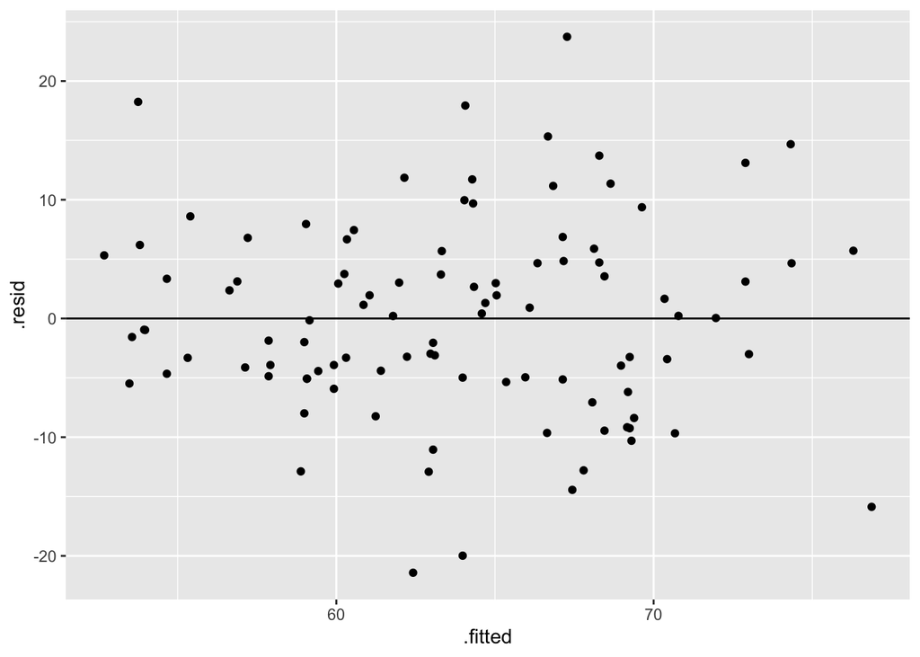

```r
ggplot(
  parenting_aug,
  aes(x = .fitted,
      y = .resid)
) +
  geom_point() +
  geom_hline(yintercept = 0)
```

There is no visible trend to the residuals. Yay, our model is usable forinference.

# 11/22 notes

This is often the case for the intercept term in a model.

## Predictions for new observations

```r
parenting_new <- read_csv("../Data/parenting_new.csv")
```

We can apply our model to these new observations using the `predict` command.

```r
predict(model, parenting_new)
```

```
       1        2
66.58701 63.84491
```

## Correlation & Spread about a line

Correlation measures the variablity of the data about the regression line. A good model can have low correlation and a bad model can have a high correlation. Correlation is a property of the data not of the model.

```r
cor(parenting$baby.sleep, parenting$dan.grump)
```

```
[1] -0.5659637
```

One drawback is that correlation can only consider a simple regression model with one explanatory variable. A closely related but more general measure of spread about a regression line is **the coefficient of determination**, or $R^2$. For a simple variable regression, this is literally just the square of the correlation.

## A second model for comparison

Let’s instead model `dan.grump` using `dan.sleep`. Let’s do this as an inference.

Null: `dan.sleep` gives no info about the mean of `dan.grump`.

Alt: it does give info.

Lets get a scatterplot.

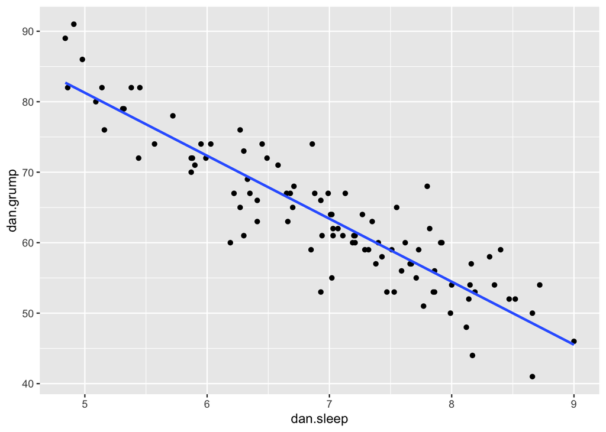

```r
ggplot(
  parenting,
  aes(x = dan.sleep,
      y = dan.grump)
) +
  geom_point() +
  geom_smooth(method = "lm",
              se = FALSE)
```

A regression seems reasonable.

```r
model_dan <- lm(dan.grump ~ dan.sleep, data = parenting)
summary(model_dan)
```

```
Call:
lm(formula = dan.grump ~ dan.sleep, data = parenting)

Residuals:
    Min      1Q  Median      3Q     Max
-11.025  -2.213  -0.399   2.681  11.750

Coefficients:
            Estimate Std. Error t value Pr(>|t|)
(Intercept) 125.9563     3.0161   41.76   <2e-16 ***
dan.sleep    -8.9368     0.4285  -20.85   <2e-16 ***
---
Signif. codes:  0 '***' 0.001 '**' 0.01 '*' 0.05 '.' 0.1 ' ' 1

Residual standard error: 4.332 on 98 degrees of freedom
Multiple R-squared:  0.8161,    Adjusted R-squared:  0.8142
F-statistic: 434.9 on 1 and 98 DF,  p-value: < 2.2e-16
```

p-value of `dan.sleep` is infinitesimally small, so the null hypothesis is not plausible. We conclude there is a relationship between `dan.sleep` and `dan.grump` in the population.

```r
cor(parenting$dan.grump, parenting$dan.sleep)
```

```
[1] -0.903384
```

Lets get a residual plot.

```r
model_dan_aug <- broom::augment(model_dan)
```

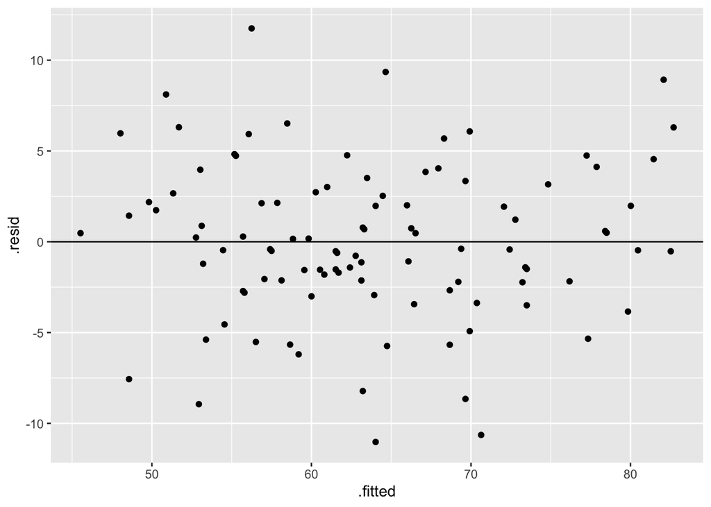

```r
ggplot(
  model_dan_aug,
  aes(x = .fitted,
      y = .resid)
) +
  geom_point() +
  geom_hline(yintercept = 0)
```

No visible trend. This regression model is reasonable for inference.

Next time: what about if we make a model using **Both** explanatory variables?

# 11/25 notes

## Two quantitative explanatory variables

A linear model with two x values looks like:

$$y = \beta_0 + \beta_1 x_1 + \beta_2 x_2$$
Where x1 is `baby.sleep`, and x2 is `dan.sleep`.

```r
model_full <- lm(dan.grump ~ baby.sleep + dan.sleep,
                 data = parenting)
summary(model_full)
```

```
Call:
lm(formula = dan.grump ~ baby.sleep + dan.sleep, data = parenting)

Residuals:
     Min       1Q   Median       3Q      Max
-11.0345  -2.2198  -0.4016   2.6775  11.7496

Coefficients:
             Estimate Std. Error t value Pr(>|t|)
(Intercept) 125.96557    3.04095  41.423   <2e-16 ***
baby.sleep    0.01052    0.27106   0.039    0.969
dan.sleep    -8.95025    0.55346 -16.172   <2e-16 ***
---
Signif. codes:  0 '***' 0.001 '**' 0.01 '*' 0.05 '.' 0.1 ' ' 1

Residual standard error: 4.354 on 97 degrees of freedom
Multiple R-squared:  0.8161,    Adjusted R-squared:  0.8123
F-statistic: 215.2 on 2 and 97 DF,  p-value: < 2.2e-16
```

Lets get all of the fitted values and residuals.

```r
parenting_full_aug <- augment(model_full)
```

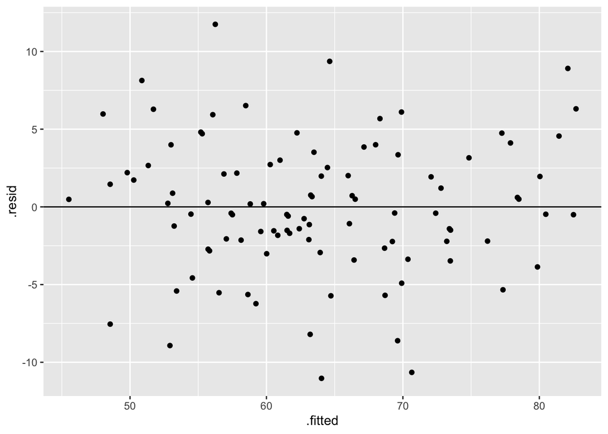

```r
ggplot(
  parenting_full_aug,
  aes(x = .fitted,
      y = .resid)
) +
  geom_point() +
  geom_hline(yintercept = 0)
```